# Single Org Results Summary

Nate Olson

June 3, 2016

## Observations

1. Overall high proportions of matches at species and genus level.
2. The cumulative match proportions do not always reach 1.00, for example *Staphylococcus* genomes. This might be due to exclusion of unclassified and unknown matches from match level analysis or reads that bowtie (mapping algorithm) was unable to align to any sequece in the reference database.
3. A number of unexpected genus, e.g. not *Bacillus*, *Clostridium*, *Escherichia*, *Francisella*, *Listeria*, *Pseudonomas*, *Salmonella*, *Shigella*, *Staphylococcus*, and *Yersinia*. These are strains that were either inadvertantly included in the study or reclassified genus.
4. Some genus have high levels of family and higher matches. For *Shigella* most likely due to matches with *Escherichia*. Will need to verify. Good discussion point highlighting the importance of considering the taxa being evaluated and taxonomic ambiguities.

## Match level by genus

Overall proportion of matches by taxonomic level. A number of strains from unexpected genus are present in the dataset. In general most matches are at the species or genus level. Species level matches include taxonomic ranks species group, species subgroup, subspecies, as well as species.

```
## geom_path: Each group consists of only one observation. Do you need to
## adjust the group aesthetic?
```

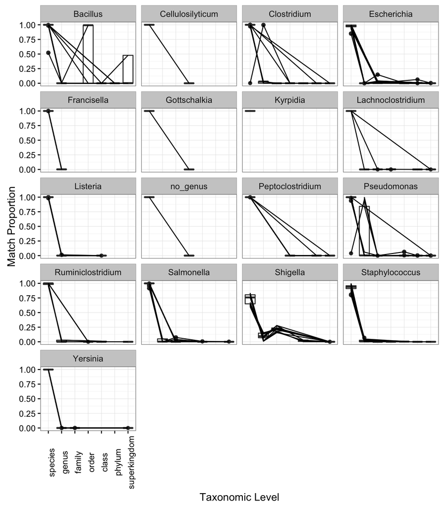

```r
singleOrgMatchResults %>%
      mutate(lca_rank = ifelse(lca_rank %in%
                                     c("species group",
                                       "species subgroup",
                                       "subspecies"),
                               "species", lca_rank),
             lca_rank = factor(lca_rank,
                               levels = c("species", "genus",
                                          "family", "order",
                                          "class","phylum",
                                          "superkingdom"))) %>%
      group_by(Query, lca_rank) %>%
      mutate(total_prop = sum(`Final Guess`)) %>%
      ggplot() + geom_boxplot(aes(x = lca_rank, y = total_prop)) +
      geom_line(aes(x = lca_rank, y = total_prop,
                               group = Query)) +
      facet_wrap(~query_genus, ncol = 4)  +
      theme_bw() + theme(axis.text.x = element_text(angle = 90)) +
      labs(x = "Taxonomic Level", y = "Match Proportion")
```

## Looking at unexpected genus

```r
singleOrgMatchResults %>%
      filter(!(query_genus %in% c("Bacillus", "Clostridium", "Escherichia",
                                  "Francisella", "Listeria", "Pseudomonas",
                                  "Salmonella", "Shigella", "Staphylococcus",
                                  "Yersinia"))) %>%
      group_by(Query, query_genus) %>%
      summarise(count = n()) %>%
      group_by(query_genus) %>%
      summarise(count = n()) %>% kable()
```

| query_genus | count |
| --- | --- |
| Cellulosilyticum | 1 |
| Gottschalkia | 1 |
| Kyrpidia | 1 |
| Lachnoclostridium | 3 |
| no_genus | 1 |
| Peptoclostridium | 10 |
| Ruminiclostridium | 6 |

### Classifications of unexpected genus

```r
unexpected_genus_df <- singleOrgMatchResults %>%
      filter(!(query_genus %in% c("Bacillus", "Clostridium", "Escherichia",
                                  "Francisella", "Listeria", "Pseudomonas",
                                  "Salmonella", "Shigella", "Staphylococcus",
                                  "Yersinia"))) %>%
      select(query_taxid, query_genus) %>% distinct()
unexpected_class <- unexpected_genus_df$query_taxid %>% classification(db = 'ncbi')
unexpected_class %>% rbind() %>% filter(rank != "no rank") %>%
      select(-id) %>% spread(rank, name) %>%
      select(query, superkingdom, phylum, class, order, family, genus, species) %>%
      arrange(class, family, genus) %>% kable()
```

| query | superkingdom | phylum | class | order | family | genus | species |
| --- | --- | --- | --- | --- | --- | --- | --- |
| 562970 | Bacteria | Firmicutes | Bacilli | Bacillales | Alicyclobacillaceae | Kyrpidia | Kyrpidia tusciae |
| 439292 | Bacteria | Firmicutes | Bacilli | Bacillales | Sporolactobacillaceae | NA | [Bacillus] selenitireducens |
| 642492 | Bacteria | Firmicutes | Clostridia | Clostridiales | Lachnospiraceae | Cellulosilyticum | Cellulosilyticum lentocellum |
| 357809 | Bacteria | Firmicutes | Clostridia | Clostridiales | Lachnospiraceae | Lachnoclostridium | Lachnoclostridium phytofermentans |
| 610130 | Bacteria | Firmicutes | Clostridia | Clostridiales | Lachnospiraceae | Lachnoclostridium | [Clostridium] saccharolyticum |
| 717608 | Bacteria | Firmicutes | Clostridia | Clostridiales | Lachnospiraceae | Lachnoclostridium | [Clostridium] saccharolyticum |
| 1511 | Bacteria | Firmicutes | Clostridia | Clostridiales | Peptostreptococcaceae | Peptoclostridium | [Clostridium] sticklandii |
| 272563 | Bacteria | Firmicutes | Clostridia | Clostridiales | Peptostreptococcaceae | Peptoclostridium | Peptoclostridium difficile |
| 645462 | Bacteria | Firmicutes | Clostridia | Clostridiales | Peptostreptococcaceae | Peptoclostridium | Peptoclostridium difficile |
| 645463 | Bacteria | Firmicutes | Clostridia | Clostridiales | Peptostreptococcaceae | Peptoclostridium | Peptoclostridium difficile |
| 699032 | Bacteria | Firmicutes | Clostridia | Clostridiales | Peptostreptococcaceae | Peptoclostridium | Peptoclostridium difficile |
| 699033 | Bacteria | Firmicutes | Clostridia | Clostridiales | Peptostreptococcaceae | Peptoclostridium | Peptoclostridium difficile |
| 699034 | Bacteria | Firmicutes | Clostridia | Clostridiales | Peptostreptococcaceae | Peptoclostridium | Peptoclostridium difficile |
| 699035 | Bacteria | Firmicutes | Clostridia | Clostridiales | Peptostreptococcaceae | Peptoclostridium | Peptoclostridium difficile |
| 699036 | Bacteria | Firmicutes | Clostridia | Clostridiales | Peptostreptococcaceae | Peptoclostridium | Peptoclostridium difficile |
| 699037 | Bacteria | Firmicutes | Clostridia | Clostridiales | Peptostreptococcaceae | Peptoclostridium | Peptoclostridium difficile |
| 1121335 | Bacteria | Firmicutes | Clostridia | Clostridiales | Ruminococcaceae | Ruminiclostridium | [Clostridium] stercorarium |
| 203119 | Bacteria | Firmicutes | Clostridia | Clostridiales | Ruminococcaceae | Ruminiclostridium | Ruminiclostridium thermocellum |
| 394503 | Bacteria | Firmicutes | Clostridia | Clostridiales | Ruminococcaceae | Ruminiclostridium | [Clostridium] cellulolyticum |
| 637887 | Bacteria | Firmicutes | Clostridia | Clostridiales | Ruminococcaceae | Ruminiclostridium | Ruminiclostridium thermocellum |
| 720554 | Bacteria | Firmicutes | Clostridia | Clostridiales | Ruminococcaceae | Ruminiclostridium | [Clostridium] clariflavum |
| 1128398 | Bacteria | Firmicutes | Clostridia | Clostridiales | NA | Gottschalkia | Gottschalkia acidurici |

## Excluding unexpected genus

```r
single_org_cum <- singleOrgMatchResults %>%
      filter(query_genus %in% c("Bacillus","Clostridium","Escherichia","Francisela","Listeria",
                                  "Pseudomonas","Salmonella","Shigella","Staphylococcus","Yersinia")) %>%
      mutate(lca_rank = ifelse(lca_rank %in%
                                     c("species group",
                                       "species subgroup",
                                       "subspecies"),
                               "species", lca_rank)) %>%
      group_by(Query, lca_rank, query_genus) %>%
      summarise(total_prop = sum(`Final Guess`)) %>%
      spread(lca_rank, total_prop,fill = 0)  %>%
      gather(lca_rank, total_prop, -Query, -query_genus)  %>%
     group_by(Query) %>%
       mutate(lca_rank = factor(lca_rank, levels = c("species", "genus",
                                    "family", "order",
                                    "class","phylum",
                                    "superkingdom"))) %>%
      arrange(lca_rank) %>%
      mutate(cum_prop = cumsum(total_prop))
```

## Single Org Genus Summary Table

Breakdown of the number of strains per genus analyzed in the study.

```r
singleOrgMatchResults %>%
      filter(query_genus %in% c("Bacillus", "Clostridium", "Escherichia",
                                  "Francisella", "Listeria", "Pseudomonas",
                                  "Salmonella", "Shigella", "Staphylococcus",
                                  "Yersinia")) %>%
      group_by(Query, query_genus) %>%
      summarise(count = n()) %>%
      group_by(query_genus) %>%
      summarise(count = n()) %>% kable()
```

| query_genus | count |
| --- | --- |
| Bacillus | 76 |
| Clostridium | 32 |
| Escherichia | 62 |
| Francisella | 18 |
| Listeria | 39 |
| Pseudomonas | 57 |
| Salmonella | 44 |
| Shigella | 10 |
| Staphylococcus | 49 |
| Yersinia | 19 |

## Cumulative match by query

The cumulative match proportions are presented in three different ways below. It is interesting that the cumulative match proportions do not always reach 1.00. This is probably due to the proportion of reads that were not mapped, this would require justification if we include this point in the manuscript.

### Faceted plots by genus

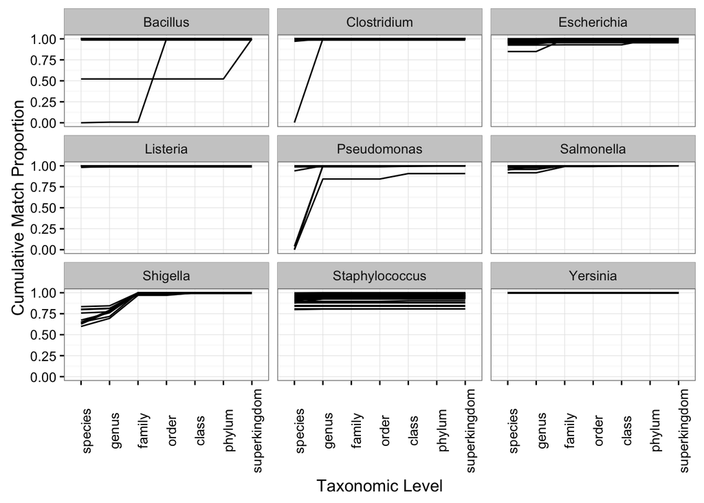

```r
ggplot(single_org_cum) +
            geom_path(aes(x = lca_rank, y = cum_prop, group = Query)) +
            facet_wrap(~query_genus) +
            theme_bw() + theme(axis.text.x = element_text(angle = 90)) +
            labs(x = "Taxonomic Level", y = "Cumulative Match Proportion")
```

### Individual Plots by genus

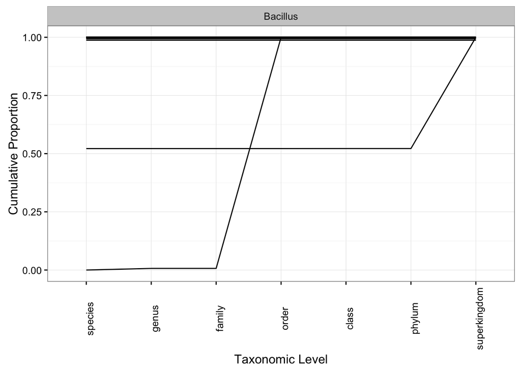

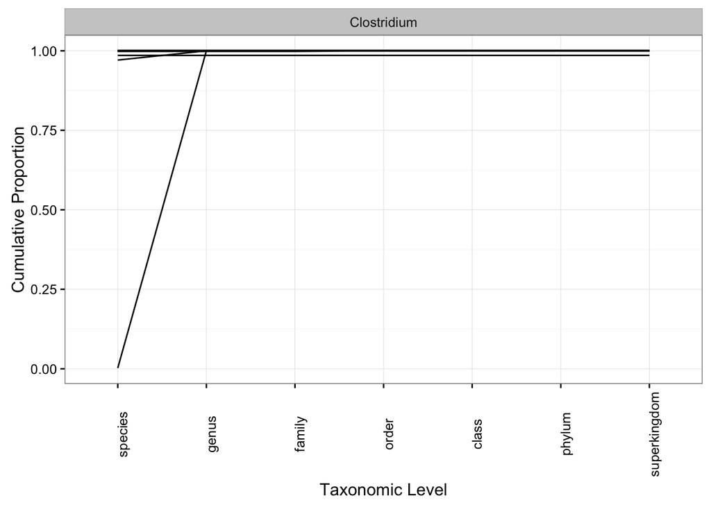

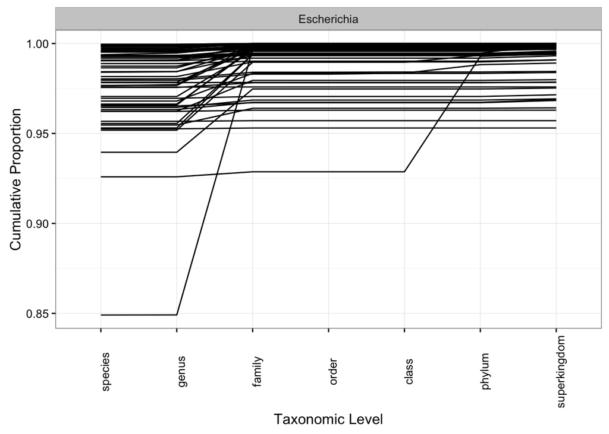

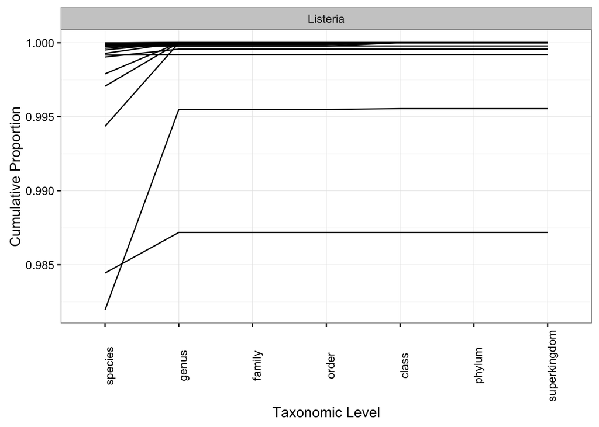

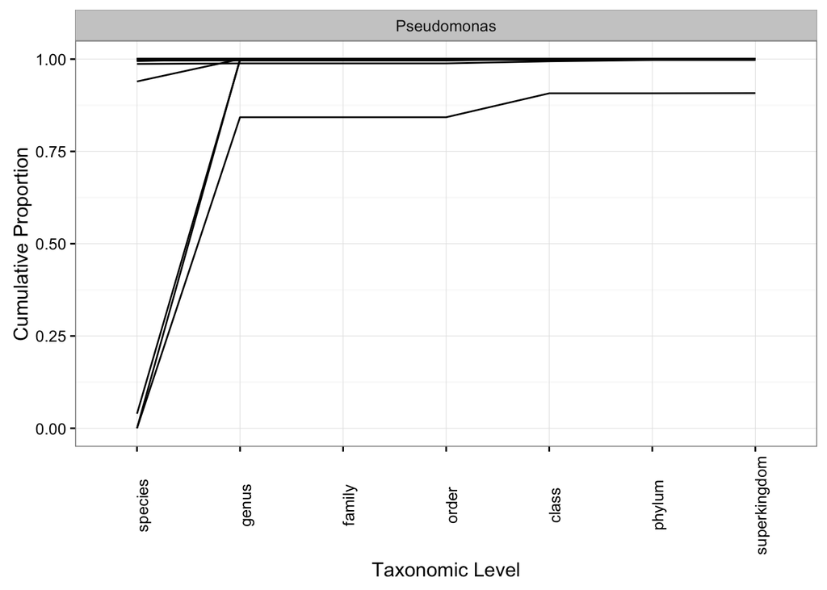

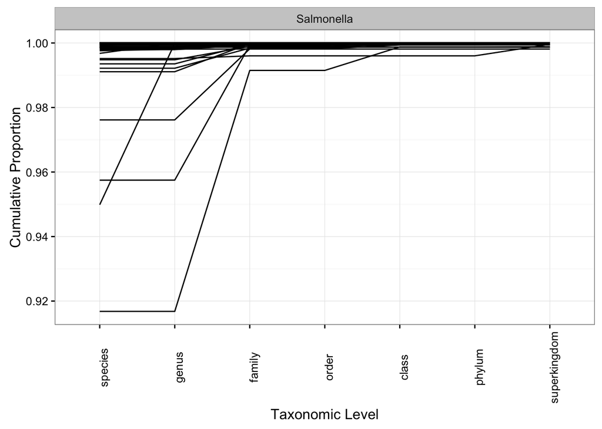

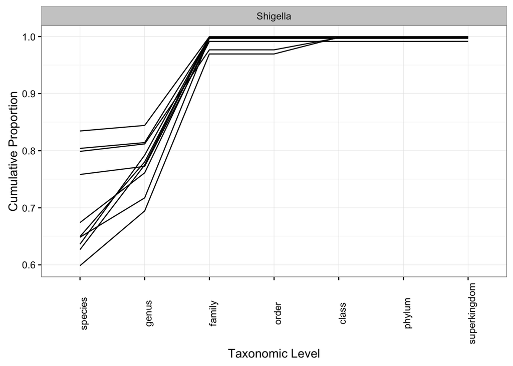

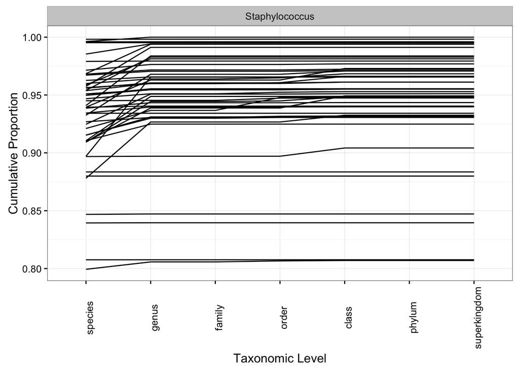

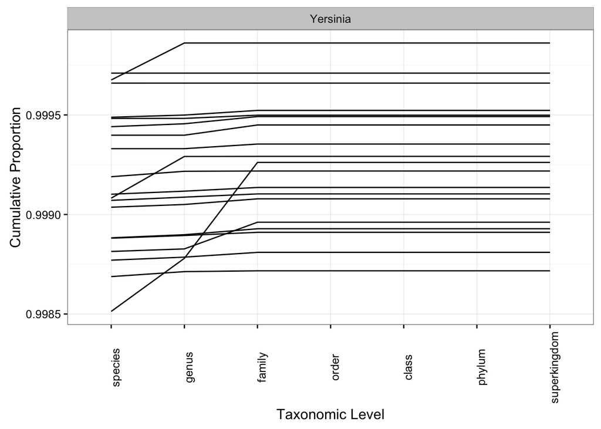

```r
plot_tax_cum <- function(df){
      p <- ggplot(df) +
            geom_path(aes(x = lca_rank, y = cum_prop, group = Query)) +
            facet_wrap(~query_genus) +
            theme_bw() + theme(axis.text.x = element_text(angle = 90)) +
            labs(x = "Taxonomic Level", y = "Cumulative Proportion")
      print(p)
}
unique(single_org_cum$query_genus) %>% as.list() %>% set_names(.) %>%
      map(~filter(single_org_cum, query_genus == .)) %>% walk(plot_tax_cum)
```

### Boxplots by genus

Boxplots to compare distributions of cumulative match proportions by taxa for individual genus.

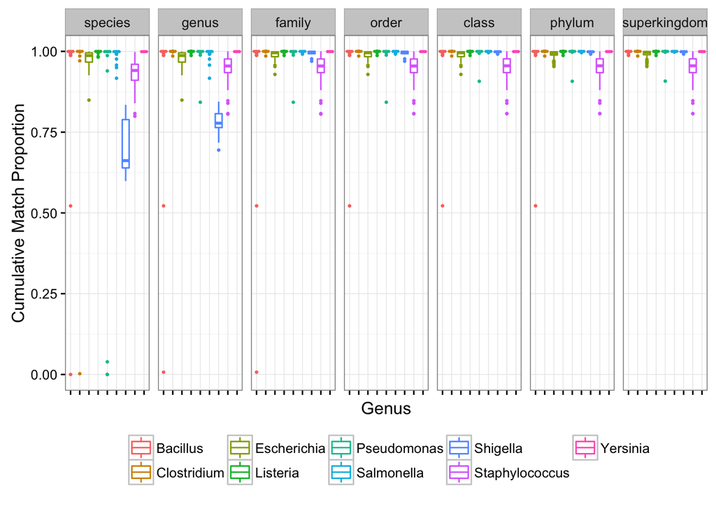

```r
ggplot(single_org_cum) +
      geom_boxplot(aes(x = query_genus, y = cum_prop, color = query_genus), outlier.size = 0.5) +
      facet_wrap(~lca_rank, nrow = 1) +
      theme_bw() + theme(axis.text.x = element_blank(), legend.position = "bottom") +
      labs(x = "Genus", color = "", y = "Cumulative Match Proportion")
```